# BSM

# 콜옵션 - 풋옵션 Payoff

변수를 다음과 같이 정의합니다.

| 변수 | 값 |
| --- | --- |
| S | 30 |
| K | 25 |
| σ | 0.1 |
| r | 0.02 |
| T | 1 |

콜옵션과 풋옵션의 Value는 다음과 같이 계산됩니다.

$$Value\ of\ Call: (S(T) - K)^+ = max\{0, S(T)-K\}$$
$$Value\ of\ Put: (K- S(T))^+ = max\{0, K - S(T)\}$$

주가와 행사가 기준 만기 Payoff와 Value는 다음과 같습니다.

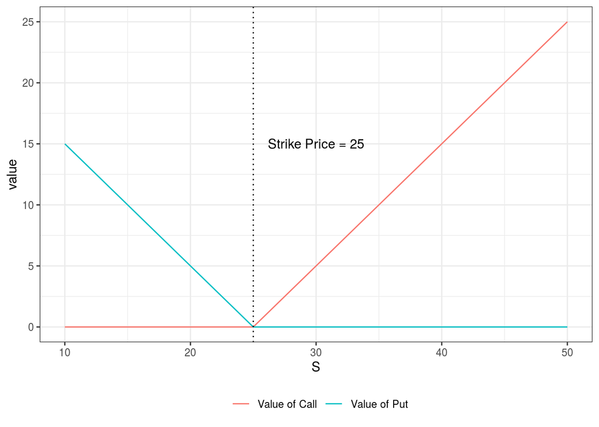

- 콜옵션: 만기시 주가가 행사가인 25보다 크면 밸류가 양수, 그렇지 않으면 0 입니다.
- 풋옵션: 만기시 주가가 행사가인 25보다 작으면 밸류가 양수, 그렇지 않으면 0 입니다.

# Closed Form

먼저 블랙숄즈옵션 모형의 Closed-Form 수식은 다음과 같습니다.

$$c = S_oN(d_1) - Ke^{-rT}N(d_2)$$
$$p = Ke^{-rT}N(-d_2) - S_oN(-d_1)$$

$$where$$

$$\begin{equation}
\begin{split}
d1 & = \frac{ln(\frac{S_o}{K}) + (r + \frac{\sigma^2}{2})T}{\sigma\sqrt{T}}\\
d2 & = \frac{ln(\frac{S_o}{K}) + (r - \frac{\sigma^2}{2})T}{\sigma\sqrt{T}}\\
& = d1 - \sigma\sqrt{T}\\
\end{split}
\end{equation}$$

각 변수에 해당하는 값들을 수식에 입력하여 콜옵션과 풋옵션의 가격을 구하도록 합니다.

```
## d1 2.073216
```

```
## d2 1.973216
```

```
## Price of call 5.5166
```

```
## Price of put 0.0216
```

온라인의 각종 BSM 계산기와 비교해도 동일한 값이 계산됩니다. (https://goodcalculators.com/black-scholes-calculator/)

# Simulation

Risk Neutral 하에서 주가는 Geometric Brownian Motion을 따른다고 가정하며, 확률과정은 다음과 같습니다.

$$ds = \mu Sdt + \sigma Sdz$$
짧은 $\Delta t$ 기간 동안 변수 $z$의 변화분은 $\Delta z$ 를 따릅니다.

$$\Delta z = \epsilon\sqrt{\Delta t}, \epsilon \sim N(0,1)$$

따라서 GBM 식을 discrete 모형으로 전환하면 다음과 같습니다.

$$\Delta S = \mu Sdt + \sigma S\epsilon\sqrt{\Delta t}, \epsilon \sim N(0,1)$$

주가의 확률과정 시뮬레이션을 위한 식은 다음과 같습니다.

$$S_{t+\Delta t} = S_t \times exp((\mu - \frac{1}{2}\sigma^2)\Delta t + \sigma \epsilon \sqrt{\Delta t}), \epsilon \sim N(0,1)$$

위 수식에 맞춰 500회의 시뮬레이션을 하도록 하며, $\Delta t$는 일간 주가의 변화를 시뮬레이션 하기 위해 $\frac{1}{255}$로 하도록 하며, $\mu$는 $r$과 같습니다.

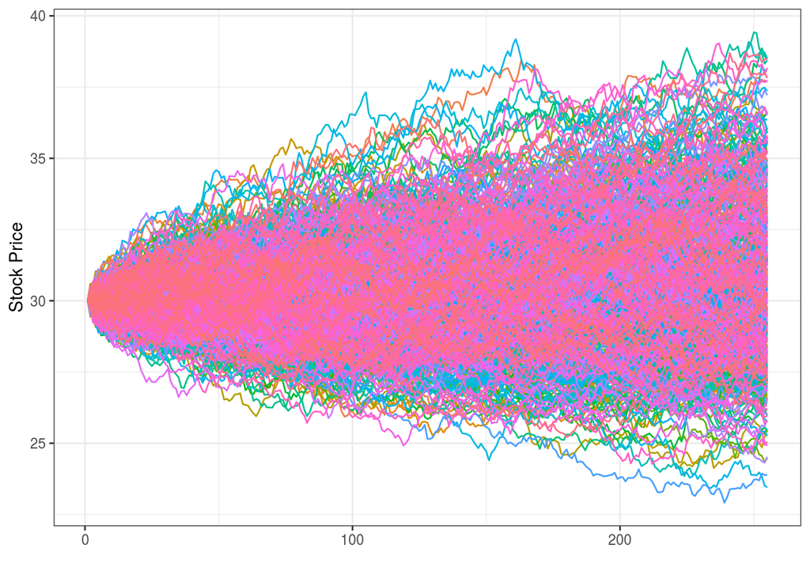

미래의 옵션 가치를 구한 후, 이들 현재가치의 평균을 구하여 콜옵션 가격을 계산하도록 합니다.

$$Call: E[e^{-rT}(max\{0, S(T)-K\})]$$
$$Put: E[e^{-rT}(max\{0, K - S(T)\})]$$

만기에 해당하는 $S(T)$의 분포는 다음과 같습니다.

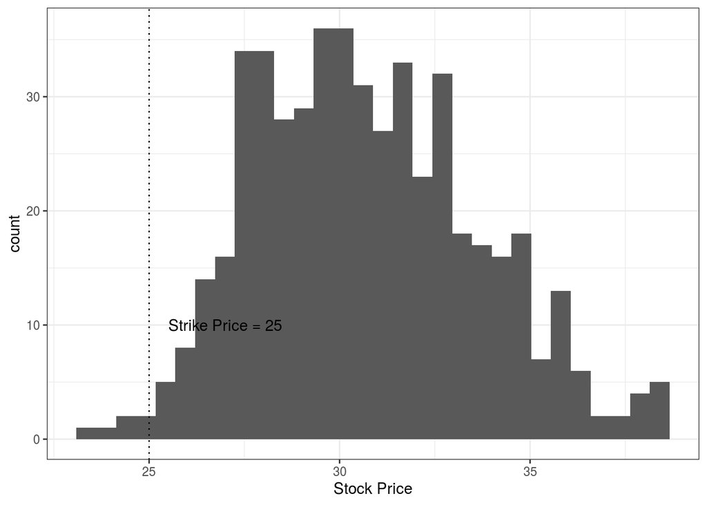

이제 해당 주가와 Strike Price를 비교해 만기 Value를 계산한 후, 이를 현재가치로 환산하여 평균을 구하도록 합니다.

```
## 5.6023 0.0074
```

Closed-Form으로 구한 값과 비교해도록 하겠습니다.

|  | Closed-Form | Simulation |
| --- | --- | --- |
| call | 5.5166 | 5.6023 |
| put | 0.0216 | 0.0074 |

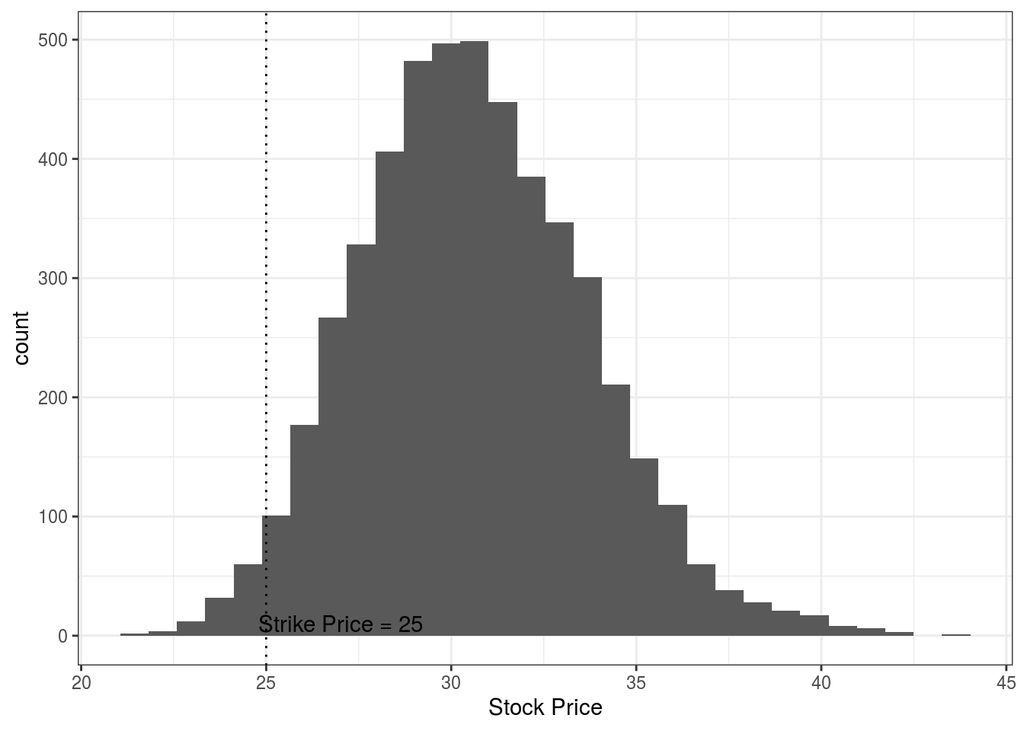

|  | Closed-Form | Simulation |
| --- | --- | --- |
| call | 5.5166 | 5.5256 |
| put | 0.0216 | 0.0212 |